# Weather ETL Pipeline Report

Author

Hailing Liao, Hailun Ma

Published

May 1, 2025

## 1 Abstract

This project implements an automated ETL (Extract-Transform-Load) pipeline using Prefect to process and store weather-related data. The objective is to collect temperature records and real-time weather conditions for U.S. states and major cities, clean and standardize the data, and load it into a SQLite database for downstream analysis.

The pipeline sources data from multiple locations: NOAA’s historical summaries and OpenWeatherMap APIs, combining both long-term climate statistics and live temperature readings. The ETL logic is modularized into separate Python scripts, and orchestrated through a Prefect flow (`pipeline_flow.py`) that automates each step in a scheduled manner.

Deployment is managed through Prefect Cloud, with the flow scheduled to run every 12 hours (43200 seconds). A dedicated process-based worker connected to a custom work pool (`weather-pool`) ensures consistent job execution. Flow runs, logs, and task statuses are fully monitored through the Prefect UI.

As a final artifact, this project generates a cleaned SQLite database file (`weather.db`) and a self-contained HTML report (this document) summarizing the pipeline. The pipeline demonstrates an end-to-end automated data engineering workflow suitable for scalable weather data collection.

## 2 Introduction

Weather and climate data play a crucial role in understanding environmental patterns, predicting natural disasters, and supporting decision-making in sectors such as agriculture, public safety, and infrastructure planning. However, collecting, transforming, and maintaining high-quality weather datasets from multiple sources is often complex and time-consuming.

This project addresses that challenge by designing a Prefect-based ETL pipeline that automates the retrieval, cleaning, transformation, and storage of weather-related data in the United States. The pipeline integrates both historical and live datasets:

- **Historical temperature data** from NOAA (state-level, monthly averages from CSV files)
- **Storm event data** from NOAA’s event summaries (by state and year)
- **Live city weather data** via the OpenWeatherMap API (for 10 major U.S. cities)

Each dataset undergoes schema validation using `pandera`, followed by a transformation step that standardizes formats and aggregates key statistics (e.g., annual average temperature, total storm events). Final outputs are merged into structured panels and saved to both CSV and a SQLite database (`weather.db`).

This project is not only a demonstration of good ETL practices and modular code design, but also a real-world application of Python tools like Prefect, SQLite, and Pandera, showcasing how to build robust pipelines for public or private data platforms.

## 3 Data Sources

This project integrates three types of weather-related datasets from authoritative sources:

### 3.1 1. NOAA State-Level Temperature Data

- **Description**: Monthly average temperature records for each U.S. state.
- **Format**: CSV files downloaded manually from the [NOAA Climate at a Glance](https://www.ncei.noaa.gov/access/monitoring/climate-at-a-glance/statewide/mapping/).
- **Years Covered**: 2020–2024
- **Access Method**: Loaded from local files in the `/data/` directory.
- **Fields Used**: `Date`, `Value` (converted to `YEAR`, `STATE`, `TEMPERATURE`)

### 3.2 2. NOAA Storm Events Summary Data

- **Description**: Storm event counts by year, state, and event type (e.g., tornado, flood, hail).
- **Format**: CSV files by year from NOAA Storm Events Database.
- **Years Covered**: 2020–2024
- **Access Method**: Loaded from local files such as `2020.csv`, `2021.csv`, etc.
- **Fields Used**: `YEAR`, `STATE`, `EVENT_TYPE`

All sources were harmonized into a single reproducible pipeline using Prefect and validated using Pandera.

## 4 ETL Pipeline Design

This project follows a modular Extract-Transform-Load (ETL) architecture implemented using Prefect for orchestration and Pandera for validation. The pipeline consists of the following main steps:

### 4.1 Extract

- **State Temperatures**: 50+ CSV files from NOAA Climate-at-a-Glance are read, each representing one U.S. state. The pipeline parses `Date` and `Value`, assigns the state name, and standardizes formats.
- **NOAA Storm Events**: Yearly storm event CSV files are read and aggregated by `YEAR`, `STATE`, and `EVENT_TYPE`.
- **City Weather (API)**: Current weather conditions for 10 major U.S. cities are fetched from the OpenWeatherMap API using secure API key access.

### 4.2 Validate

Each raw input is validated with Pandera schemas: - State temperature data is checked for valid `STATE`, string `DATE`, and a temperature range of -50 to 130 °F. - Storm event records must have non-null categorical and integer values. - Merged data is also validated before writing to disk or database.

### 4.3 Transform

- State-level temperature data is aggregated from monthly to annual averages.
- Storm events are grouped to annual total counts per state.
- The two datasets are merged by `YEAR` and `STATE` to form a unified panel.

### 4.5 Orchestration

All stages are defined as Prefect tasks and composed into a unified `@flow` function named `weather_etl_pipeline`. The pipeline is scheduled and monitored using Prefect Cloud, with logs and task statuses available in the UI.

## 5 Results & Screenshots

### 5.1 1. Successful ETL Pipeline Run

The screenshot below shows a successful end-to-end execution of the `weather_etl_pipeline` flow from the terminal. All key tasks—including data extraction, validation, transformation, and saving to both CSV and SQLite—completed successfully.

Key outputs include: - 5 NOAA storm event files loaded (2020–2024) - Merged state-level panel written to `extracted_data/state_panel.csv` - Real-time and forecast city-level weather data saved to `extracted_data/city_weather.csv` - Final records inserted into the `weather.db` SQLite database

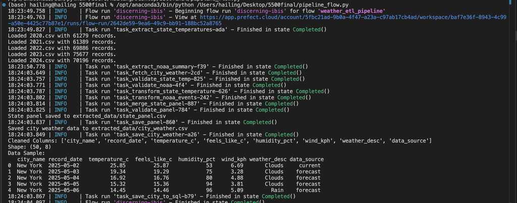

Successful Run

## 6 Results and Summary

The ETL pipeline successfully processed and consolidated complex, multi-source weather datasets into structured, analyzable outputs.

### 6.1 Data Complexity

- State-level temperature files: Over 50 separate files (e.g., `alabama.csv`, `florida.csv`), each containing monthly averages spanning multiple years.
- Annual storm event summaries: Files from 2020 to 2024 listing event type and frequency by state.
- Real-time city weather data: Fetched via API for 10 major U.S. cities, including temperature, humidity, wind, and conditions.

Each source required custom extraction logic, schema validation using Pandera, and harmonization of data types and formats.

### 6.2 Pipeline Outputs

The resulting data is ready for downstream analysis and visualization.

```python
import pandas as pd

# Load and display part of the cleaned state-level panel
df_state = pd.read_csv("extracted_data/state_panel.csv")
print("State-level temperature & storm panel (sample):")
df_state.head()
```

```
State-level temperature & storm panel (sample):
```

|  | YEAR | STATE | AVG_TEMP | EVENT_COUNT |
| --- | --- | --- | --- | --- |
| 0 | 2020 | ALABAMA | 65.258333 | 1353 |
| 1 | 2020 | ALASKA | 28.425000 | 252 |
| 2 | 2020 | ARIZONA | 61.575000 | 816 |
| 3 | 2020 | ARKANSAS | 61.458333 | 1138 |
| 4 | 2020 | CALIFORNIA | 59.541667 | 1828 |

```python
df_city = pd.read_csv("extracted_data/city_weather.csv")
print("City-level weather snapshot (sample):")
df_city.head()
```

```
City-level weather snapshot (sample):
```

|  | city | date | temperature | feels_like | humidity | wind_speed | weather | source |
| --- | --- | --- | --- | --- | --- | --- | --- | --- |
| 0 | New York | 2025-05-02 | 25.85 | 25.87 | 53 | 6.69 | Clouds | current |
| 1 | New York | 2025-05-03 | 19.34 | 19.29 | 75 | 3.28 | Clouds | forecast |
| 2 | New York | 2025-05-04 | 16.92 | 16.76 | 80 | 4.88 | Clouds | forecast |
| 3 | New York | 2025-05-05 | 15.32 | 15.36 | 94 | 3.81 | Clouds | forecast |
| 4 | New York | 2025-05-06 | 14.45 | 14.46 | 96 | 5.09 | Rain | forecast |

## 7 Code

This section includes all scripts used to implement the ETL pipeline.

### 7.1 Extracted

```python
# extract_state_temperature.py
with open("extract_state_temperatures.py") as f:
    print("### extract_state_temperatures.py\n")
    print(f.read())

# extract_noaa_summary.py
with open("extract_noaa_summary.py") as f:
    print("\n### extract_noaa_summary.py\n")
    print(f.read())

# city_api.py
with open("city_api.py") as f:
    print("\n### city_api.py\n")
    print(f.read())
```

```
### extract_state_temperatures.py

import pandas as pd
import os
from typing import List

def extract_state_temperatures(data_dir: str = "data/") -> pd.DataFrame:
    """
    Load and combine monthly average temperature data for all US states from individual CSV files.

    Parameters:
        data_dir (str): Path to the directory containing state temperature CSVs

    Returns:
        pd.DataFrame: Combined table with columns ['STATE', 'DATE', 'TEMPERATURE']
    """
    all_states = []

    for filename in os.listdir(data_dir):
        if filename.endswith(".csv") and filename not in ["us_tem.csv"] and filename[0].isalpha():
            state = filename.replace(".csv", "").lower()
            file_path = os.path.join(data_dir, filename)
            try:
                df = pd.read_csv(file_path, usecols=["Date", "Value"])
                df["STATE"] = state
                df.rename(columns={"Date": "DATE", "Value": "TEMPERATURE"}, inplace=True)
                all_states.append(df)
            except Exception as e:
                print(f"Error reading {filename}: {e}")

    if not all_states:
        raise ValueError("No valid state temperature files found.")

    result = pd.concat(all_states, ignore_index=True)
    return result[["STATE", "DATE", "TEMPERATURE"]]


### extract_noaa_summary.py

import pandas as pd
```

[output cut: 118 more lines]

```
    """
    all_dfs = []

    for city in cities:
        try:
            df = fetch_city_weather(api_key, city)
            all_dfs.append(df)
            time.sleep(1)
        except Exception as e:
            print(f"Error fetching data for {city}: {e}")

    if not all_dfs:
        return pd.DataFrame()

    return pd.concat(all_dfs, ignore_index=True)
```

### 7.2 Transform

```python
# === transform.py ===
with open("transform.py") as f:
    print("\n### transform.py\n")
    print(f.read())
```

```
### transform.py

import pandas as pd

def transform_state_temperature(df: pd.DataFrame) -> pd.DataFrame:
    """
    Aggregate monthly temperatures into annual average per state.

    Parameters:
        df (pd.DataFrame): Input with columns [STATE, DATE, TEMPERATURE]

    Returns:
        pd.DataFrame: Output with [YEAR, STATE, AVG_TEMP]
    """
    df["YEAR"] = df["DATE"].astype(str).str[:4].astype(int)
    df["STATE"] = df["STATE"].str.upper().str.strip()
    result = (
        df.groupby(["YEAR", "STATE"], as_index=False)
          .agg(AVG_TEMP=("TEMPERATURE", "mean"))
    )
    return result


def transform_noaa_events(df: pd.DataFrame) -> pd.DataFrame:
    """
    Aggregate total storm events per state per year.

    Parameters:
        df (pd.DataFrame): Input with columns [YEAR, STATE, EVENT_TYPE, TOTAL_EVENTS]

    Returns:
        pd.DataFrame: Output with [YEAR, STATE, EVENT_COUNT]
    """
    df["STATE"] = df["STATE"].str.upper().str.strip()
    result = (
        df.groupby(["YEAR", "STATE"], as_index=False)
          .agg(EVENT_COUNT=("TOTAL_EVENTS", "sum"))
    )
    return result


def merge_state_panel(temp_df: pd.DataFrame, event_df: pd.DataFrame) -> pd.DataFrame:
    """
    Merge annual temperature and event count per state.

    Parameters:
        temp_df (pd.DataFrame): Output from transform_state_temperature
        event_df (pd.DataFrame): Output from transform_noaa_events

    Returns:
        pd.DataFrame: Merged panel with [YEAR, STATE, AVG_TEMP, EVENT_COUNT]
    """
    return pd.merge(temp_df, event_df, on=["YEAR", "STATE"], how="inner")
```

### 7.3 Validation

```python
# === validate.py ===
with open("validate.py") as f:
    print("\n### validate.py\n")
    print(f.read())
```

```
### validate.py

import pandas as pd
import pandera as pa
from pandera import Column, DataFrameSchema, Check


# 1. Schema for raw state-level temperature data
state_temp_schema = DataFrameSchema({
    "STATE": Column(pa.String, nullable=False),
    "DATE": Column(pa.String, checks=Check.str_length(6), nullable=False),
    "TEMPERATURE": Column(pa.Float, checks=Check.in_range(-50, 130), nullable=False),
})


# 2. Schema for NOAA summarized storm events
noaa_schema = DataFrameSchema({
    "YEAR": Column(pa.Int, checks=Check.in_range(2020, 2024)),
    "STATE": Column(pa.String, nullable=False),
    "EVENT_TYPE": Column(pa.String, nullable=False),
    "TOTAL_EVENTS": Column(pa.Int, checks=Check.ge(0), nullable=False),
})


# 3. Schema for merged state-level panel data
state_panel_schema = DataFrameSchema({
    "YEAR": Column(pa.Int, checks=Check.in_range(2020, 2024)),
    "STATE": Column(pa.String, nullable=False),
    "AVG_TEMP": Column(pa.Float, checks=Check.in_range(-50, 130)),
    "EVENT_COUNT": Column(pa.Int, checks=Check.ge(0)),
})


# === Validation functions ===

def validate_state_temp(df: pd.DataFrame) -> pd.DataFrame:
    """
    Validate state-level temperature data using Pandera schema.
    """
    df["DATE"] = df["DATE"].astype(str)
    return state_temp_schema.validate(df)


def validate_noaa(df: pd.DataFrame) -> pd.DataFrame:
    """
    Validate NOAA summary data using Pandera schema.
    """
    return noaa_schema.validate(df)


def validate_state_panel(df: pd.DataFrame) -> pd.DataFrame:
    """
    Validate final merged panel data using Pandera schema.
    """
    return state_panel_schema.validate(df)
```

### 7.4 Load

```python
# === load.py ===
with open("load.py") as f:
    print("\n### load.py\n")
    print(f.read())
```

```
### load.py

import pandas as pd
import sqlite3

def save_state_panel(panel_df: pd.DataFrame, output_path: str = "extracted_data/state_panel.csv"):
    """
    Save the final merged panel data to CSV.

    Parameters:
        panel_df (pd.DataFrame): DataFrame with columns [YEAR, STATE, AVG_TEMP, EVENT_COUNT]
        output_path (str): Path to save the CSV
    """
    panel_df.to_csv(output_path, index=False)
    print(f"State panel saved to {output_path}")

def save_city_weather_to_sql(df, db_path="extracted_data/weather.db", table_name="city_weather"):
    import re

    rename_map = {
        "city": "city_name",
        "date": "record_date",
        "temperature": "temperature_c",
        "feels_like": "feels_like_c",
        "humidity": "humidity_pct",
        "wind_speed": "wind_kph",
        "weather": "weather_desc",
        "source": "data_source"
    }
    df = df.rename(columns=rename_map)

    df.columns = [re.sub(r"\W+", "_", str(col)).strip("_") for col in df.columns]

    conn = sqlite3.connect(db_path)
    df.to_sql(table_name, conn, if_exists="replace", index=False)
    conn.close()
```

### 7.5 Pipeline

```python
# === pipeline_flow.py ===
with open("pipeline_flow.py") as f:
    print("\n### pipeline_flow.py\n")
    print(f.read())
```

```
### pipeline_flow.py

from prefect import flow, task
import pandas as pd
import os
from dotenv import load_dotenv
import sqlite3
import re

# Load environment variables
load_dotenv()
api_key = os.getenv("WEATHER_API_KEY")

# === Import Extract modules ===
from extract_state_temperatures import extract_state_temperatures
from extract_noaa_summary import extract_noaa_summary
from city_api import fetch_multiple_cities

# === Import Transform modules ===
from transform import (
    transform_state_temperature,
    transform_noaa_events,
    merge_state_panel
)

# === Import Validation modules ===
from validate import (
    validate_state_temp,
    validate_noaa,
    validate_state_panel
)

# === Import Load module ===
from load import save_state_panel


# === Prefect Tasks ===

@task
def task_extract_state_temperatures(data_dir: str) -> pd.DataFrame:
```

[output cut: 101 more lines]

```
    panel = task_merge_state_panel(temp_transformed, noaa_transformed)
    validated_panel = task_validate_panel(panel)

    # Save to CSV
    task_save_panel(validated_panel, output_path)
    task_save_city_weather(city_weather)

    # Save to SQLite
    task_save_city_to_sql(city_weather)


if __name__ == "__main__":
    if not api_key:
        raise ValueError("API key not found. Check your .env file.")
    main_pipeline(api_key=api_key)
```

### 7.6 Test

```python
# === test_extract.py ===
with open("test_extract.py") as f:
    print("\n### test_extract.py\n")
    print(f.read())

# === test_city_api.py ===
with open("test_city_api.py") as f:
    print("\n### test_city_api.py\n")
    print(f.read())

# === test_transform.py ===
with open("test_transform.py") as f:
    print("\n### test_transform.py\n")
    print(f.read())

# === test_validate.py ===
with open("test_validate.py") as f:
    print("\n### test_validate.py\n")
    print(f.read())

# === test_load.py ===
with open("test_load.py") as f:
    print("\n### test_load.py\n")
    print(f.read())
```

```
### test_extract.py

# test_extract.py

import pandas as pd
import pytest
from extract_state_temperatures import extract_state_temperatures
from extract_noaa_summary import extract_noaa_summary
import os

def test_extract_state_temperatures(tmp_path):
    # Create dummy file
    file = tmp_path / "texas.csv"
    file.write_text("Date,Value\n2020-01,10.5\n2020-02,12.1")

    df = extract_state_temperatures(str(tmp_path))
    assert not df.empty
    assert set(df.columns) == {"STATE", "DATE", "TEMPERATURE"}
    assert df.iloc[0]["STATE"] == "texas"

def test_extract_noaa_summary(tmp_path):
    # Create dummy NOAA file
    file = tmp_path / "2020.csv"
    file.write_text("YEAR,STATE,EVENT_TYPE\n2020,TEXAS,Storm\n2020,TEXAS,Flood")

    df = extract_noaa_summary(str(tmp_path))
    assert not df.empty
    assert set(df.columns) == {"YEAR", "STATE", "EVENT_TYPE", "TOTAL_EVENTS"}
    assert df["TOTAL_EVENTS"].sum() == 2


### test_city_api.py

# test_city_api.py

import pytest
import pandas as pd
from city_api import fetch_city_weather

def test_fetch_city_weather_mock(monkeypatch):
```

[output cut: 189 more lines]

```
        "wind_speed": [3.2],
        "weather": ["Rain"],
        "source": ["forecast"]
    })

    db_path = tmp_path / "weather_test.db"
    save_city_weather_to_sql(df, str(db_path))

    # Connect to DB and check contents
    conn = sqlite3.connect(str(db_path))
    result_df = pd.read_sql("SELECT * FROM city_weather", conn)
    conn.close()

    # Should match original DataFrame
    pd.testing.assert_frame_equal(result_df, df)
```